# Supervised Learning : Exploring Boosting, Bagging and Stacking Algorithms for Ensemble Learning

John Pauline Pineda

August 19, 2023

# **1. Table of Contents**

## 1.1 Sample Data

The [**Wisconsin Breast Cancer**](https://www.kaggle.com/datasets/uciml/breast-cancer-wisconsin-data) dataset shared from the [**Kaggle**](https://www.kaggle.com/) website as obtained from the [UCI Machine Learning Repository](https://archive.ics.uci.edu/) was used for this illustrated example.  
Preliminary dataset assessment:  
**[A]** 1138 rows (observations)  
**[B]** 32 columns (variables)  
**[B.1]** 1/32 metadata (unique identifiers) = id (numeric)  
**[B.2]** 1/32 response = diagnosis (factor)  
**[B.3]** 30/32 predictors = 30/30 numeric  
**[B.3.1]** radius_mean (numeric)  
**[B.3.2]** texture_mean (numeric)  
**[B.3.3]** perimeter_mean (numeric)  
**[B.3.4]** area_mean (numeric)  
**[B.3.5]** smoothness_mean (numeric)  
**[B.3.6]** compactness_mean (numeric)  
**[B.3.7]** concavity_mean (numeric)  
**[B.3.8]** concave.points_mean (numeric)  
**[B.3.9]** symmetry_mean (numeric)  
**[B.3.10]** fractal_dimension_mean (numeric)  
**[B.3.11]** radius_se (numeric)  
**[B.3.12]** texture_se (numeric)  
**[B.3.13]** perimeter_se (numeric)  
**[B.3.14]** area_se (numeric)  
**[B.3.15]** smoothness_se (numeric)  
**[B.3.16]** compactness_se (numeric)  
**[B.3.17]** concavity_se (numeric)  
**[B.3.18]** concave.points_se (numeric)  
**[B.3.19]** symmetry_se (numeric)  
**[B.3.20]** fractal_dimension_se (numeric)  
**[B.3.21]** radius_worst (numeric)  
**[B.3.22]** texture_worst (numeric)  
**[B.3.23]** perimeter_worst (numeric)  
**[B.3.24]** area_worst (numeric)  
**[B.3.25]** smoothness_worst (numeric)  
**[B.3.26]** compactness_worst (numeric)  
**[B.3.27]** concavity_worst (numeric)  
**[B.3.28]** concave.points_worst (numeric)  
**[B.3.29]** symmetry_worst (numeric)  
**[B.3.30]** fractal_dimension_worst (numeric)

**Code Chunk | Output**

```r
##################################
# Loading R libraries
##################################
library(AppliedPredictiveModeling)
library(tidyr)
library(caret)
library(lattice)
library(dplyr)
library(moments)
library(skimr)
library(RANN)
library(pls)
library(corrplot)
library(lares)
library(DMwR)
library(gridExtra)
library(rattle)
library(RColorBrewer)
library(stats)
library(caretEnsemble)
library(pROC)

##################################
# Loading source and
# formulating the analysis set
##################################
BreastCancer <- read.csv("WisconsinBreastCancer.csv",
                   na.strings=c("NA","NaN"," ",""),
                   stringsAsFactors = FALSE)
BreastCancer <- as.data.frame(BreastCancer)

##################################
# Performing a general exploration of the data set
##################################
dim(BreastCancer)
```

```
## [1] 1138   32
```

```r
str(BreastCancer)
```

```
## 'data.frame':    1138 obs. of  32 variables:
##  $ id                     : int  842302 842517 84300903 84348301 84358402 843786 844359 84458202 844981 84501001 ...
##  $ diagnosis              : chr  "M" "M" "M" "M" ...
##  $ radius_mean            : num  18 20.6 19.7 11.4 20.3 ...
##  $ texture_mean           : num  10.4 17.8 21.2 20.4 14.3 ...
##  $ perimeter_mean         : num  122.8 132.9 130 77.6 135.1 ...
##  $ area_mean              : num  1001 1326 1203 386 1297 ...
##  $ smoothness_mean        : num  0.1184 0.0847 0.1096 0.1425 0.1003 ...
##  $ compactness_mean       : num  0.2776 0.0786 0.1599 0.2839 0.1328 ...
##  $ concavity_mean         : num  0.3001 0.0869 0.1974 0.2414 0.198 ...
##  $ concave.points_mean    : num  0.1471 0.0702 0.1279 0.1052 0.1043 ...
##  $ symmetry_mean          : num  0.242 0.181 0.207 0.26 0.181 ...
##  $ fractal_dimension_mean : num  0.0787 0.0567 0.06 0.0974 0.0588 ...
##  $ radius_se              : num  1.095 0.543 0.746 0.496 0.757 ...
##  $ texture_se             : num  0.905 0.734 0.787 1.156 0.781 ...
```

[output cut: 18 more lines]

```r
summary(BreastCancer)
```

```
##        id             diagnosis          radius_mean      texture_mean
##  Min.   :     8670   Length:1138        Min.   : 6.981   Min.   : 9.71
##  1st Qu.:   869218   Class :character   1st Qu.:11.700   1st Qu.:16.17
##  Median :   906024   Mode  :character   Median :13.370   Median :18.84
##  Mean   : 30371831                      Mean   :14.127   Mean   :19.29
##  3rd Qu.:  8813129                      3rd Qu.:15.780   3rd Qu.:21.80
##  Max.   :911320502                      Max.   :28.110   Max.   :39.28
##  perimeter_mean     area_mean      smoothness_mean   compactness_mean
##  Min.   : 43.79   Min.   : 143.5   Min.   :0.05263   Min.   :0.01938
##  1st Qu.: 75.17   1st Qu.: 420.3   1st Qu.:0.08637   1st Qu.:0.06492
##  Median : 86.24   Median : 551.1   Median :0.09587   Median :0.09263
##  Mean   : 91.97   Mean   : 654.9   Mean   :0.09636   Mean   :0.10434
##  3rd Qu.:104.10   3rd Qu.: 782.7   3rd Qu.:0.10530   3rd Qu.:0.13040
##  Max.   :188.50   Max.   :2501.0   Max.   :0.16340   Max.   :0.34540
##  concavity_mean    concave.points_mean symmetry_mean    fractal_dimension_mean
##  Min.   :0.00000   Min.   :0.00000     Min.   :0.1060   Min.   :0.04996
##  1st Qu.:0.02956   1st Qu.:0.02031     1st Qu.:0.1619   1st Qu.:0.05770
##  Median :0.06154   Median :0.03350     Median :0.1792   Median :0.06154
##  Mean   :0.08880   Mean   :0.04892     Mean   :0.1812   Mean   :0.06280
##  3rd Qu.:0.13070   3rd Qu.:0.07400     3rd Qu.:0.1957   3rd Qu.:0.06612
##  Max.   :0.42680   Max.   :0.20120     Max.   :0.3040   Max.   :0.09744
##    radius_se        texture_se      perimeter_se       area_se
##  Min.   :0.1115   Min.   :0.3602   Min.   : 0.757   Min.   :  6.802
##  1st Qu.:0.2324   1st Qu.:0.8339   1st Qu.: 1.606   1st Qu.: 17.850
##  Median :0.3242   Median :1.1080   Median : 2.287   Median : 24.530
##  Mean   :0.4052   Mean   :1.2169   Mean   : 2.866   Mean   : 40.337
##  3rd Qu.:0.4789   3rd Qu.:1.4740   3rd Qu.: 3.357   3rd Qu.: 45.190
##  Max.   :2.8730   Max.   :4.8850   Max.   :21.980   Max.   :542.200
##  smoothness_se      compactness_se      concavity_se     concave.points_se
##  Min.   :0.001713   Min.   :0.002252   Min.   :0.00000   Min.   :0.000000
##  1st Qu.:0.005169   1st Qu.:0.013080   1st Qu.:0.01509   1st Qu.:0.007638
##  Median :0.006380   Median :0.020450   Median :0.02589   Median :0.010930
##  Mean   :0.007041   Mean   :0.025478   Mean   :0.03189   Mean   :0.011796
##  3rd Qu.:0.008146   3rd Qu.:0.032450   3rd Qu.:0.04205   3rd Qu.:0.014710
##  Max.   :0.031130   Max.   :0.135400   Max.   :0.39600   Max.   :0.052790
##   symmetry_se       fractal_dimension_se  radius_worst   texture_worst
##  Min.   :0.007882   Min.   :0.0008948    Min.   : 7.93   Min.   :12.02
##  1st Qu.:0.015160   1st Qu.:0.0022480    1st Qu.:13.01   1st Qu.:21.08
##  Median :0.018730   Median :0.0031870    Median :14.97   Median :25.41
##  Mean   :0.020542   Mean   :0.0037949    Mean   :16.27   Mean   :25.68
##  3rd Qu.:0.023480   3rd Qu.:0.0045580    3rd Qu.:18.79   3rd Qu.:29.72
##  Max.   :0.078950   Max.   :0.0298400    Max.   :36.04   Max.   :49.54
##  perimeter_worst    area_worst     smoothness_worst  compactness_worst
##  Min.   : 50.41   Min.   : 185.2   Min.   :0.07117   Min.   :0.02729
##  1st Qu.: 84.11   1st Qu.: 515.3   1st Qu.:0.11660   1st Qu.:0.14720
##  Median : 97.66   Median : 686.5   Median :0.13130   Median :0.21190
##  Mean   :107.26   Mean   : 880.6   Mean   :0.13237   Mean   :0.25427
##  3rd Qu.:125.40   3rd Qu.:1084.0   3rd Qu.:0.14600   3rd Qu.:0.33910
##  Max.   :251.20   Max.   :4254.0   Max.   :0.22260   Max.   :1.05800
##  concavity_worst  concave.points_worst symmetry_worst   fractal_dimension_worst
##  Min.   :0.0000   Min.   :0.00000      Min.   :0.1565   Min.   :0.05504
##  1st Qu.:0.1145   1st Qu.:0.06493      1st Qu.:0.2504   1st Qu.:0.07146
##  Median :0.2267   Median :0.09993      Median :0.2822   Median :0.08004
##  Mean   :0.2722   Mean   :0.11461      Mean   :0.2901   Mean   :0.08395
##  3rd Qu.:0.3829   3rd Qu.:0.16140      3rd Qu.:0.3179   3rd Qu.:0.09208
##  Max.   :1.2520   Max.   :0.29100      Max.   :0.6638   Max.   :0.20750
```

```r
##################################
# Setting the data type
# for the response variable
##################################
BreastCancer$diagnosis <- factor(BreastCancer$diagnosis,
                                 levels = c("B","M"))

##################################
# Formulating a data type assessment summary
##################################
PDA <- BreastCancer
(PDA.Summary <- data.frame(
  Column.Index=c(1:length(names(PDA))),
  Column.Name= names(PDA),
  Column.Type=sapply(PDA, function(x) class(x)),
  row.names=NULL)
)
```

```
##    Column.Index             Column.Name Column.Type
## 1             1                      id     integer
## 2             2               diagnosis      factor
## 3             3             radius_mean     numeric
## 4             4            texture_mean     numeric
## 5             5          perimeter_mean     numeric
## 6             6               area_mean     numeric
## 7             7         smoothness_mean     numeric
## 8             8        compactness_mean     numeric
## 9             9          concavity_mean     numeric
## 10           10     concave.points_mean     numeric
## 11           11           symmetry_mean     numeric
## 12           12  fractal_dimension_mean     numeric
## 13           13               radius_se     numeric
## 14           14              texture_se     numeric
```

[output cut: 18 more lines]

## 1.2 Data Quality Assessment

**[A]** No missing observations noted for any predictor.  
**[B]** Low variance observed for 1 predictor with First.Second.Mode.Ratio>5.  
**[B.1]** concavity_se = 6.50  
**[C]** No low variance observed for any predictor with Unique.Count.Ratio<0.01.  
**[D]** High skewness observed for 5 predictors with Skewness>3 or Skewness<(-3).  
**[D.1]** radius_se = +3.08  
**[D.2]** perimeter_se = +3.43  
**[D.3]** area_se = +5.43  
**[D.4]** concavity_se = +5.10  
**[D.5]** fractal_dimension_se = +3.91

**Code Chunk | Output**

```r
##################################
# Loading dataset
##################################
DQA <- BreastCancer

##################################
# Formulating an overall data quality assessment summary
##################################
(DQA.Summary <- data.frame(
  Column.Name= names(DQA),
  Column.Type=sapply(DQA, function(x) class(x)),
  Row.Count=sapply(DQA, function(x) nrow(DQA)),
  NA.Count=sapply(DQA,function(x)sum(is.na(x))),
  Fill.Rate=sapply(DQA,function(x)format(round((sum(!is.na(x))/nrow(DQA)),3),nsmall=3)),
  row.names=NULL)
)
```

```
##                Column.Name Column.Type Row.Count NA.Count Fill.Rate
## 1                       id     integer      1138        0     1.000
## 2                diagnosis      factor      1138        0     1.000
## 3              radius_mean     numeric      1138        0     1.000
## 4             texture_mean     numeric      1138        0     1.000
## 5           perimeter_mean     numeric      1138        0     1.000
## 6                area_mean     numeric      1138        0     1.000
## 7          smoothness_mean     numeric      1138        0     1.000
## 8         compactness_mean     numeric      1138        0     1.000
## 9           concavity_mean     numeric      1138        0     1.000
## 10     concave.points_mean     numeric      1138        0     1.000
## 11           symmetry_mean     numeric      1138        0     1.000
## 12  fractal_dimension_mean     numeric      1138        0     1.000
## 13               radius_se     numeric      1138        0     1.000
## 14              texture_se     numeric      1138        0     1.000
```

[output cut: 18 more lines]

```r
##################################
# Listing all Predictors
##################################
DQA.Predictors <- DQA[,!names(DQA) %in% c("id","diagnosis")]

##################################
# Listing all numeric Predictors
##################################
DQA.Predictors.Numeric <- DQA.Predictors[,sapply(DQA.Predictors, is.numeric)]

if (length(names(DQA.Predictors.Numeric))>0) {
    print(paste0("There are ",
               (length(names(DQA.Predictors.Numeric))),
               " numeric predictor variable(s)."))
} else {
  print("There are no numeric predictor variables.")
}
```

```
## [1] "There are 30 numeric predictor variable(s)."
```

```r
##################################
# Listing all factor Predictors
##################################
DQA.Predictors.Factor <- DQA.Predictors[,sapply(DQA.Predictors, is.factor)]

if (length(names(DQA.Predictors.Factor))>0) {
    print(paste0("There are ",
               (length(names(DQA.Predictors.Factor))),
               " factor predictor variable(s)."))
} else {
  print("There are no factor predictor variables.")
}
```

```
## [1] "There are no factor predictor variables."
```

```r
##################################
# Formulating a data quality assessment summary for factor Predictors
##################################
if (length(names(DQA.Predictors.Factor))>0) {

  ##################################
  # Formulating a function to determine the first mode
  ##################################
  FirstModes <- function(x) {
    ux <- unique(na.omit(x))
    tab <- tabulate(match(x, ux))
    ux[tab == max(tab)]
  }

  ##################################
  # Formulating a function to determine the second mode
  ##################################
  SecondModes <- function(x) {
    ux <- unique(na.omit(x))
    tab <- tabulate(match(x, ux))
    fm = ux[tab == max(tab)]
    sm = x[!(x %in% fm)]
    usm <- unique(sm)
    tabsm <- tabulate(match(sm, usm))
    ifelse(is.na(usm[tabsm == max(tabsm)])==TRUE,
           return("x"),
           return(usm[tabsm == max(tabsm)]))
  }

  (DQA.Predictors.Factor.Summary <- data.frame(
  Column.Name= names(DQA.Predictors.Factor),
  Column.Type=sapply(DQA.Predictors.Factor, function(x) class(x)),
  Unique.Count=sapply(DQA.Predictors.Factor, function(x) length(unique(x))),
  First.Mode.Value=sapply(DQA.Predictors.Factor, function(x) as.character(FirstModes(x)[1])),
  Second.Mode.Value=sapply(DQA.Predictors.Factor, function(x) as.character(SecondModes(x)[1])),
  First.Mode.Count=sapply(DQA.Predictors.Factor, function(x) sum(na.omit(x) == FirstModes(x)[1])),
  Second.Mode.Count=sapply(DQA.Predictors.Factor, function(x) sum(na.omit(x) == SecondModes(x)[1])),
  Unique.Count.Ratio=sapply(DQA.Predictors.Factor, function(x) format(round((length(unique(x))/nrow(DQA.Predictors.Factor)),3), nsmall=3)),
  First.Second.Mode.Ratio=sapply(DQA.Predictors.Factor, function(x) format(round((sum(na.omit(x) == FirstModes(x)[1])/sum(na.omit(x) == SecondModes(x)[1])),3), nsmall=3)),
  row.names=NULL)
  )

}

##################################
# Formulating a data quality assessment summary for numeric Predictors
##################################
if (length(names(DQA.Predictors.Numeric))>0) {

  ##################################
  # Formulating a function to determine the first mode
  ##################################
  FirstModes <- function(x) {
    ux <- unique(na.omit(x))
    tab <- tabulate(match(x, ux))
    ux[tab == max(tab)]
  }

  ##################################
  # Formulating a function to determine the second mode
  ##################################
  SecondModes <- function(x) {
    ux <- unique(na.omit(x))
    tab <- tabulate(match(x, ux))
    fm = ux[tab == max(tab)]
    sm = na.omit(x)[!(na.omit(x) %in% fm)]
    usm <- unique(sm)
    tabsm <- tabulate(match(sm, usm))
    ifelse(is.na(usm[tabsm == max(tabsm)])==TRUE,
           return(0.00001),
           return(usm[tabsm == max(tabsm)]))
  }

  (DQA.Predictors.Numeric.Summary <- data.frame(
  Column.Name= names(DQA.Predictors.Numeric),
  Column.Type=sapply(DQA.Predictors.Numeric, function(x) class(x)),
  Unique.Count=sapply(DQA.Predictors.Numeric, function(x) length(unique(x))),
  Unique.Count.Ratio=sapply(DQA.Predictors.Numeric, function(x) format(round((length(unique(x))/nrow(DQA.Predictors.Numeric)),3), nsmall=3)),
  First.Mode.Value=sapply(DQA.Predictors.Numeric, function(x) format(round((FirstModes(x)[1]),3),nsmall=3)),
  Second.Mode.Value=sapply(DQA.Predictors.Numeric, function(x) format(round((SecondModes(x)[1]),3),nsmall=3)),
  First.Mode.Count=sapply(DQA.Predictors.Numeric, function(x) sum(na.omit(x) == FirstModes(x)[1])),
  Second.Mode.Count=sapply(DQA.Predictors.Numeric, function(x) sum(na.omit(x) == SecondModes(x)[1])),
  First.Second.Mode.Ratio=sapply(DQA.Predictors.Numeric, function(x) format(round((sum(na.omit(x) == FirstModes(x)[1])/sum(na.omit(x) == SecondModes(x)[1])),3), nsmall=3)),
  Minimum=sapply(DQA.Predictors.Numeric, function(x) format(round(min(x,na.rm = TRUE),3), nsmall=3)),
  Mean=sapply(DQA.Predictors.Numeric, function(x) format(round(mean(x,na.rm = TRUE),3), nsmall=3)),
  Median=sapply(DQA.Predictors.Numeric, function(x) format(round(median(x,na.rm = TRUE),3), nsmall=3)),
  Maximum=sapply(DQA.Predictors.Numeric, function(x) format(round(max(x,na.rm = TRUE),3), nsmall=3)),
  Skewness=sapply(DQA.Predictors.Numeric, function(x) format(round(skewness(x,na.rm = TRUE),3), nsmall=3)),
  Kurtosis=sapply(DQA.Predictors.Numeric, function(x) format(round(kurtosis(x,na.rm = TRUE),3), nsmall=3)),
  Percentile25th=sapply(DQA.Predictors.Numeric, function(x) format(round(quantile(x,probs=0.25,na.rm = TRUE),3), nsmall=3)),
  Percentile75th=sapply(DQA.Predictors.Numeric, function(x) format(round(quantile(x,probs=0.75,na.rm = TRUE),3), nsmall=3)),
  row.names=NULL)
  )

}
```

```
##                Column.Name Column.Type Unique.Count Unique.Count.Ratio
## 1              radius_mean     numeric          456              0.401
## 2             texture_mean     numeric          479              0.421
## 3           perimeter_mean     numeric          522              0.459
## 4                area_mean     numeric          539              0.474
## 5          smoothness_mean     numeric          474              0.417
## 6         compactness_mean     numeric          537              0.472
## 7           concavity_mean     numeric          537              0.472
## 8      concave.points_mean     numeric          542              0.476
## 9            symmetry_mean     numeric          432              0.380
## 10  fractal_dimension_mean     numeric          499              0.438
## 11               radius_se     numeric          540              0.475
## 12              texture_se     numeric          519              0.456
## 13            perimeter_se     numeric          533              0.468
## 14                 area_se     numeric          528              0.464
```

[output cut: 109 more lines]

```r
##################################
# Identifying potential data quality issues
##################################

##################################
# Checking for missing observations
##################################
if ((nrow(DQA.Summary[DQA.Summary$NA.Count>0,]))>0){
  print(paste0("Missing observations noted for ",
               (nrow(DQA.Summary[DQA.Summary$NA.Count>0,])),
               " variable(s) with NA.Count>0 and Fill.Rate<1.0."))
  DQA.Summary[DQA.Summary$NA.Count>0,]
} else {
  print("No missing observations noted.")
}
```

```
## [1] "No missing observations noted."
```

```r
##################################
# Checking for zero or near-zero variance Predictors
##################################
if (length(names(DQA.Predictors.Factor))==0) {
  print("No factor predictors noted.")
} else if (nrow(DQA.Predictors.Factor.Summary[as.numeric(as.character(DQA.Predictors.Factor.Summary$First.Second.Mode.Ratio))>5,])>0){
  print(paste0("Low variance observed for ",
               (nrow(DQA.Predictors.Factor.Summary[as.numeric(as.character(DQA.Predictors.Factor.Summary$First.Second.Mode.Ratio))>5,])),
               " factor variable(s) with First.Second.Mode.Ratio>5."))
  DQA.Predictors.Factor.Summary[as.numeric(as.character(DQA.Predictors.Factor.Summary$First.Second.Mode.Ratio))>5,]
} else {
  print("No low variance factor predictors due to high first-second mode ratio noted.")
}
```

```
## [1] "No factor predictors noted."
```

```r
if (length(names(DQA.Predictors.Numeric))==0) {
  print("No numeric predictors noted.")
} else if (nrow(DQA.Predictors.Numeric.Summary[as.numeric(as.character(DQA.Predictors.Numeric.Summary$First.Second.Mode.Ratio))>5,])>0){
  print(paste0("Low variance observed for ",
               (nrow(DQA.Predictors.Numeric.Summary[as.numeric(as.character(DQA.Predictors.Numeric.Summary$First.Second.Mode.Ratio))>5,])),
               " numeric variable(s) with First.Second.Mode.Ratio>5."))
  DQA.Predictors.Numeric.Summary[as.numeric(as.character(DQA.Predictors.Numeric.Summary$First.Second.Mode.Ratio))>5,]
} else {
  print("No low variance numeric predictors due to high first-second mode ratio noted.")
}
```

```
## [1] "Low variance observed for 1 numeric variable(s) with First.Second.Mode.Ratio>5."
```

```
##     Column.Name Column.Type Unique.Count Unique.Count.Ratio First.Mode.Value
## 17 concavity_se     numeric          533              0.468            0.000
##    Second.Mode.Value First.Mode.Count Second.Mode.Count First.Second.Mode.Ratio
## 17             0.017               26                 4                   6.500
##    Minimum  Mean Median Maximum Skewness Kurtosis Percentile25th Percentile75th
## 17   0.000 0.032  0.026   0.396    5.097   51.423          0.015          0.042
```

```r
if (length(names(DQA.Predictors.Numeric))==0) {
  print("No numeric predictors noted.")
} else if (nrow(DQA.Predictors.Numeric.Summary[as.numeric(as.character(DQA.Predictors.Numeric.Summary$Unique.Count.Ratio))<0.01,])>0){
  print(paste0("Low variance observed for ",
               (nrow(DQA.Predictors.Numeric.Summary[as.numeric(as.character(DQA.Predictors.Numeric.Summary$Unique.Count.Ratio))<0.01,])),
               " numeric variable(s) with Unique.Count.Ratio<0.01."))
  DQA.Predictors.Numeric.Summary[as.numeric(as.character(DQA.Predictors.Numeric.Summary$Unique.Count.Ratio))<0.01,]
} else {
  print("No low variance numeric predictors due to low unique count ratio noted.")
}
```

```
## [1] "No low variance numeric predictors due to low unique count ratio noted."
```

```r
##################################
# Checking for skewed Predictors
##################################
if (length(names(DQA.Predictors.Numeric))==0) {
  print("No numeric predictors noted.")
} else if (nrow(DQA.Predictors.Numeric.Summary[as.numeric(as.character(DQA.Predictors.Numeric.Summary$Skewness))>3 |
                                               as.numeric(as.character(DQA.Predictors.Numeric.Summary$Skewness))<(-3),])>0){
  print(paste0("High skewness observed for ",
  (nrow(DQA.Predictors.Numeric.Summary[as.numeric(as.character(DQA.Predictors.Numeric.Summary$Skewness))>3 |
                                               as.numeric(as.character(DQA.Predictors.Numeric.Summary$Skewness))<(-3),])),
  " numeric variable(s) with Skewness>3 or Skewness<(-3)."))
  DQA.Predictors.Numeric.Summary[as.numeric(as.character(DQA.Predictors.Numeric.Summary$Skewness))>3 |
                                 as.numeric(as.character(DQA.Predictors.Numeric.Summary$Skewness))<(-3),]
} else {
  print("No skewed numeric predictors noted.")
}
```

```
## [1] "High skewness observed for 5 numeric variable(s) with Skewness>3 or Skewness<(-3)."
```

```
##             Column.Name Column.Type Unique.Count Unique.Count.Ratio
## 11            radius_se     numeric          540              0.475
## 13         perimeter_se     numeric          533              0.468
## 14              area_se     numeric          528              0.464
## 17         concavity_se     numeric          533              0.468
## 20 fractal_dimension_se     numeric          545              0.479
##    First.Mode.Value Second.Mode.Value First.Mode.Count Second.Mode.Count
## 11            0.286             0.298                6                 4
## 13            1.778             2.406                8                 4
## 14           16.970            74.080                6                 4
## 17            0.000             0.017               26                 4
## 20            0.003             0.006                4                 2
##    First.Second.Mode.Ratio Minimum   Mean Median Maximum Skewness Kurtosis
## 11                   1.500   0.112  0.405  0.324   2.873    3.080   20.521
## 13                   2.000   0.757  2.866  2.287  21.980    3.435   24.204
## 14                   1.500   6.802 40.337 24.530 542.200    5.433   51.767
## 17                   6.500   0.000  0.032  0.026   0.396    5.097   51.423
## 20                   2.000   0.001  0.004  0.003   0.030    3.914   29.040
##    Percentile25th Percentile75th
## 11          0.232          0.479
## 13          1.606          3.357
## 14         17.850         45.190
## 17          0.015          0.042
## 20          0.002          0.005
```

## 1.3 Data Preprocessing

### 1.3.1 Outlier Detection

**[A]** Outliers noted for 29 out of the 30 predictors. Predictor values were visualized through a boxplot including observations classified as suspected outliers using the IQR criterion. The IQR criterion means that all observations above the (75th percentile + 1.5 x IQR) or below the (25th percentile - 1.5 x IQR) are suspected outliers, where IQR is the difference between the third quartile (75th percentile) and first quartile (25th percentile).  
**[A.1]** radius_mean = 28  
**[A.2]** texture_mean = 14  
**[A.3]** perimeter_mean = 26  
**[A.4]** area_mean = 50  
**[A.5]** smoothness_mean = 12  
**[A.6]** compactness_mean = 32  
**[A.7]** concavity_mean = 36  
**[A.8]** concave.points_mean = 20  
**[A.9]** symmetry_mean = 30  
**[A.10]** fractal_dimension_mean = 30  
**[A.11]** radius_se = 76  
**[A.12]** texture_se = 40  
**[A.13]** perimeter_se = 76  
**[A.14]** area_se = 130  
**[A.15]** smoothness_se = 60  
**[A.16]** compactness_se = 56  
**[A.17]** concavity_se = 44  
**[A.18]** concave.points_se = 38  
**[A.19]** symmetry_se = 54  
**[A.20]** fractal_dimension_se = 56  
**[A.21]** radius_worst = 34  
**[A.22]** texture_worst = 10  
**[A.23]** perimeter_worst = 30  
**[A.24]** area_worst = 70  
**[A.25]** smoothness_worst = 14  
**[A.26]** compactness_worst = 32  
**[A.27]** concavity_worst = 24  
**[A.28]** symmetry_worst = 46  
**[A.29]** fractal_dimension_worst = 48

**Code Chunk | Output**

```r
##################################
# Loading dataset
##################################
DPA <- DQA[,!names(DQA) %in% c("id")]

##################################
# Gathering descriptive statistics
##################################
(DPA_Skimmed <- skim(DPA))
```

Data summary

| Name | DPA |
| --- | --- |
| Number of rows | 1138 |
| Number of columns | 31 |
| _______________________ |  |
| Column type frequency: |  |
| factor | 1 |
| numeric | 30 |
| ________________________ |  |
| Group variables | None |

**Variable type: factor**

| skim_variable | n_missing | complete_rate | ordered | n_unique | top_counts |
| --- | --- | --- | --- | --- | --- |
| diagnosis | 0 | 1 | FALSE | 2 | B: 714, M: 424 |

**Variable type: numeric**

| skim_variable | n_missing | complete_rate | mean | sd | p0 | p25 | p50 | p75 | p100 | hist |
| --- | --- | --- | --- | --- | --- | --- | --- | --- | --- | --- |
| radius_mean | 0 | 1 | 14.13 | 3.52 | 6.98 | 11.70 | 13.37 | 15.78 | 28.11 | ▂▇▃▁▁ |
| texture_mean | 0 | 1 | 19.29 | 4.30 | 9.71 | 16.17 | 18.84 | 21.80 | 39.28 | ▃▇▃▁▁ |
| perimeter_mean | 0 | 1 | 91.97 | 24.29 | 43.79 | 75.17 | 86.24 | 104.10 | 188.50 | ▃▇▃▁▁ |
| area_mean | 0 | 1 | 654.89 | 351.76 | 143.50 | 420.30 | 551.10 | 782.70 | 2501.00 | ▇▃▂▁▁ |
| smoothness_mean | 0 | 1 | 0.10 | 0.01 | 0.05 | 0.09 | 0.10 | 0.11 | 0.16 | ▁▇▇▁▁ |
| compactness_mean | 0 | 1 | 0.10 | 0.05 | 0.02 | 0.06 | 0.09 | 0.13 | 0.35 | ▇▇▂▁▁ |
| concavity_mean | 0 | 1 | 0.09 | 0.08 | 0.00 | 0.03 | 0.06 | 0.13 | 0.43 | ▇▃▂▁▁ |
| concave.points_mean | 0 | 1 | 0.05 | 0.04 | 0.00 | 0.02 | 0.03 | 0.07 | 0.20 | ▇▃▂▁▁ |
| symmetry_mean | 0 | 1 | 0.18 | 0.03 | 0.11 | 0.16 | 0.18 | 0.20 | 0.30 | ▁▇▅▁▁ |
| fractal_dimension_mean | 0 | 1 | 0.06 | 0.01 | 0.05 | 0.06 | 0.06 | 0.07 | 0.10 | ▆▇▂▁▁ |
| radius_se | 0 | 1 | 0.41 | 0.28 | 0.11 | 0.23 | 0.32 | 0.48 | 2.87 | ▇▁▁▁▁ |
| texture_se | 0 | 1 | 1.22 | 0.55 | 0.36 | 0.83 | 1.11 | 1.47 | 4.88 | ▇▅▁▁▁ |
| perimeter_se | 0 | 1 | 2.87 | 2.02 | 0.76 | 1.61 | 2.29 | 3.36 | 21.98 | ▇▁▁▁▁ |
| area_se | 0 | 1 | 40.34 | 45.47 | 6.80 | 17.85 | 24.53 | 45.19 | 542.20 | ▇▁▁▁▁ |
| smoothness_se | 0 | 1 | 0.01 | 0.00 | 0.00 | 0.01 | 0.01 | 0.01 | 0.03 | ▇▃▁▁▁ |
| compactness_se | 0 | 1 | 0.03 | 0.02 | 0.00 | 0.01 | 0.02 | 0.03 | 0.14 | ▇▃▁▁▁ |
| concavity_se | 0 | 1 | 0.03 | 0.03 | 0.00 | 0.02 | 0.03 | 0.04 | 0.40 | ▇▁▁▁▁ |
| concave.points_se | 0 | 1 | 0.01 | 0.01 | 0.00 | 0.01 | 0.01 | 0.01 | 0.05 | ▇▇▁▁▁ |
| symmetry_se | 0 | 1 | 0.02 | 0.01 | 0.01 | 0.02 | 0.02 | 0.02 | 0.08 | ▇▃▁▁▁ |
| fractal_dimension_se | 0 | 1 | 0.00 | 0.00 | 0.00 | 0.00 | 0.00 | 0.00 | 0.03 | ▇▁▁▁▁ |
| radius_worst | 0 | 1 | 16.27 | 4.83 | 7.93 | 13.01 | 14.97 | 18.79 | 36.04 | ▆▇▃▁▁ |
| texture_worst | 0 | 1 | 25.68 | 6.14 | 12.02 | 21.08 | 25.41 | 29.72 | 49.54 | ▃▇▆▁▁ |
| perimeter_worst | 0 | 1 | 107.26 | 33.59 | 50.41 | 84.11 | 97.66 | 125.40 | 251.20 | ▇▇▃▁▁ |
| area_worst | 0 | 1 | 880.58 | 569.11 | 185.20 | 515.30 | 686.50 | 1084.00 | 4254.00 | ▇▂▁▁▁ |
| smoothness_worst | 0 | 1 | 0.13 | 0.02 | 0.07 | 0.12 | 0.13 | 0.15 | 0.22 | ▂▇▇▂▁ |
| compactness_worst | 0 | 1 | 0.25 | 0.16 | 0.03 | 0.15 | 0.21 | 0.34 | 1.06 | ▇▅▁▁▁ |
| concavity_worst | 0 | 1 | 0.27 | 0.21 | 0.00 | 0.11 | 0.23 | 0.38 | 1.25 | ▇▅▂▁▁ |
| concave.points_worst | 0 | 1 | 0.11 | 0.07 | 0.00 | 0.06 | 0.10 | 0.16 | 0.29 | ▅▇▅▃▁ |
| symmetry_worst | 0 | 1 | 0.29 | 0.06 | 0.16 | 0.25 | 0.28 | 0.32 | 0.66 | ▅▇▁▁▁ |
| fractal_dimension_worst | 0 | 1 | 0.08 | 0.02 | 0.06 | 0.07 | 0.08 | 0.09 | 0.21 | ▇▃▁▁▁ |

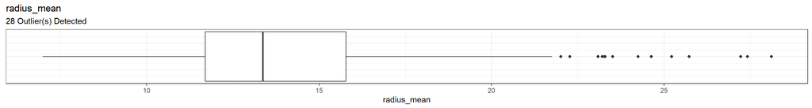

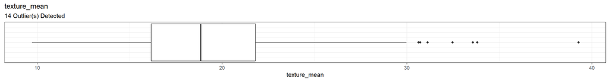

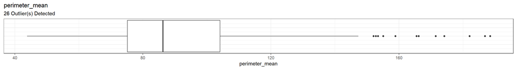

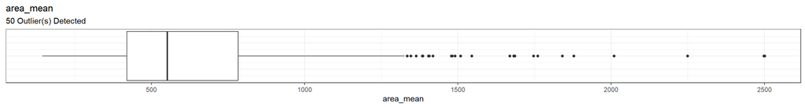

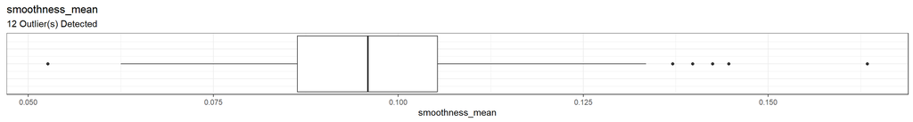

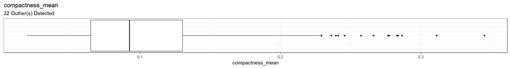

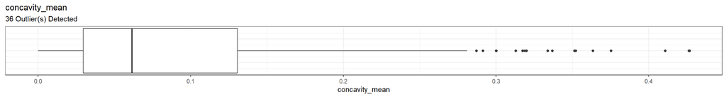

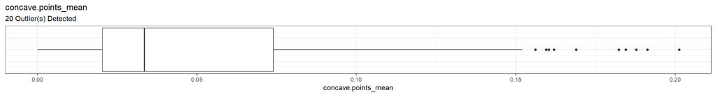

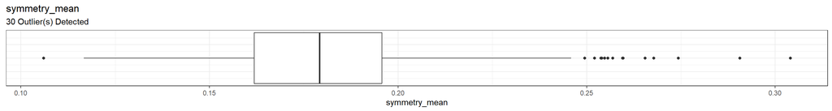

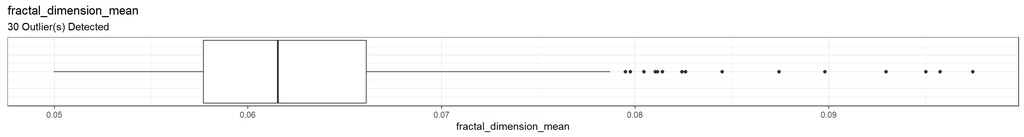

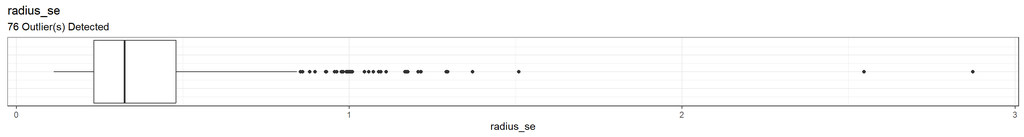

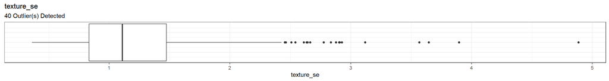

[18 more figures not shown]

```r
##################################
# Outlier Detection
##################################

##################################
# Listing all Predictors
##################################
DPA.Predictors <- DPA[,!names(DPA) %in% c("diagnosis")]

##################################
# Listing all numeric Predictors
##################################
DPA.Predictors.Numeric <- DPA.Predictors[,sapply(DPA.Predictors, is.numeric)]

##################################
# Identifying outliers for the numeric Predictors
##################################
OutlierCountList <- c()

for (i in 1:ncol(DPA.Predictors.Numeric)) {
  Outliers <- boxplot.stats(DPA.Predictors.Numeric[,i])$out
  OutlierCount <- length(Outliers)
  OutlierCountList <- append(OutlierCountList,OutlierCount)
  OutlierIndices <- which(DPA.Predictors.Numeric[,i] %in% c(Outliers))
  print(
  ggplot(DPA.Predictors.Numeric, aes(x=DPA.Predictors.Numeric[,i])) +
  geom_boxplot() +
  theme_bw() +
  theme(axis.text.y=element_blank(),
        axis.ticks.y=element_blank()) +
  xlab(names(DPA.Predictors.Numeric)[i]) +
  labs(title=names(DPA.Predictors.Numeric)[i],
       subtitle=paste0(OutlierCount, " Outlier(s) Detected")))
}
```

### 1.3.2 Zero and Near-Zero Variance

**Code Chunk | Output**

```r
##################################
# Zero and Near-Zero Variance
##################################

##################################
# Identifying columns with low variance
###################################
DPA_LowVariance <- nearZeroVar(DPA,
                               freqCut = 80/20,
                               uniqueCut = 10,
                               saveMetrics= TRUE)
(DPA_LowVariance[DPA_LowVariance$nzv,])
```

```
## [1] freqRatio     percentUnique zeroVar       nzv
## <0 rows> (or 0-length row.names)
```

```r
if ((nrow(DPA_LowVariance[DPA_LowVariance$nzv,]))==0){

  print("No low variance descriptors noted.")

} else {

  print(paste0("Low variance observed for ",
               (nrow(DPA_LowVariance[DPA_LowVariance$nzv,])),
               " numeric variable(s) with First.Second.Mode.Ratio>4 and Unique.Count.Ratio<0.10."))

  DPA_LowVarianceForRemoval <- (nrow(DPA_LowVariance[DPA_LowVariance$nzv,]))

  print(paste0("Low variance can be resolved by removing ",
               (nrow(DPA_LowVariance[DPA_LowVariance$nzv,])),
               " numeric variable(s)."))

  for (j in 1:DPA_LowVarianceForRemoval) {
  DPA_LowVarianceRemovedVariable <- rownames(DPA_LowVariance[DPA_LowVariance$nzv,])[j]
  print(paste0("Variable ",
               j,
               " for removal: ",
               DPA_LowVarianceRemovedVariable))
  }

  DPA %>%
  skim() %>%
  dplyr::filter(skim_variable %in% rownames(DPA_LowVariance[DPA_LowVariance$nzv,]))

}
```

```
## [1] "No low variance descriptors noted."
```

### 1.3.3 Collinearity

**Code Chunk | Output**

```r
##################################
# Visualizing pairwise correlation between Predictor
##################################
(DPA_Correlation <- cor(DPA.Predictors.Numeric,
                        method = "pearson",
                        use="pairwise.complete.obs"))
```

```
##                          radius_mean texture_mean perimeter_mean    area_mean
## radius_mean              1.000000000  0.323781891    0.997855281  0.987357170
## texture_mean             0.323781891  1.000000000    0.329533059  0.321085696
## perimeter_mean           0.997855281  0.329533059    1.000000000  0.986506804
## area_mean                0.987357170  0.321085696    0.986506804  1.000000000
## smoothness_mean          0.170581187 -0.023388516    0.207278164  0.177028377
## compactness_mean         0.506123578  0.236702222    0.556936211  0.498501682
## concavity_mean           0.676763550  0.302417828    0.716135650  0.685982829
## concave.points_mean      0.822528522  0.293464051    0.850977041  0.823268869
## symmetry_mean            0.147741242  0.071400980    0.183027212  0.151293079
## fractal_dimension_mean  -0.311630826 -0.076437183   -0.261476908 -0.283109812
## radius_se                0.679090388  0.275868676    0.691765014  0.732562227
## texture_se              -0.097317443  0.386357623   -0.086761078 -0.066280214
## perimeter_se             0.674171616  0.281673115    0.693134890  0.726628328
## area_se                  0.735863663  0.259844987    0.744982694  0.800085921
## smoothness_se           -0.222600125  0.006613777   -0.202694026 -0.166776667
## compactness_se           0.205999980  0.191974611    0.250743681  0.212582551
## concavity_se             0.194203623  0.143293077    0.228082345  0.207660060
## concave.points_se        0.376168956  0.163851025    0.407216916  0.372320282
## symmetry_se             -0.104320881  0.009127168   -0.081629327 -0.072496588
## fractal_dimension_se    -0.042641269  0.054457520   -0.005523391 -0.019886963
## radius_worst             0.969538973  0.352572947    0.969476363  0.962746086
## texture_worst            0.297007644  0.912044589    0.303038372  0.287488627
## perimeter_worst          0.965136514  0.358039575    0.970386887  0.959119574
## area_worst               0.941082460  0.343545947    0.941549808  0.959213326
## smoothness_worst         0.119616140  0.077503359    0.150549404  0.123522939
## compactness_worst        0.413462823  0.277829592    0.455774228  0.390410309
## concavity_worst          0.526911462  0.301025224    0.563879263  0.512605920
## concave.points_worst     0.744214198  0.295315843    0.771240789  0.722016626
## symmetry_worst           0.163953335  0.105007910    0.189115040  0.143569914
## fractal_dimension_worst  0.007065886  0.119205351    0.051018530  0.003737597
##                         smoothness_mean compactness_mean concavity_mean
## radius_mean                  0.17058119       0.50612358     0.67676355
## texture_mean                -0.02338852       0.23670222     0.30241783
## perimeter_mean               0.20727816       0.55693621     0.71613565
## area_mean                    0.17702838       0.49850168     0.68598283
## smoothness_mean              1.00000000       0.65912322     0.52198377
## compactness_mean             0.65912322       1.00000000     0.88312067
## concavity_mean               0.52198377       0.88312067     1.00000000
## concave.points_mean          0.55369517       0.83113504     0.92139103
```

[output cut: 255 more lines]

```
## compactness_se              0.27787843             0.590972763
## concavity_se                0.19778782             0.439329269
## concave.points_se           0.14311567             0.310654551
## symmetry_se                 0.38940248             0.078079476
## fractal_dimension_se        0.11109396             0.591328066
## radius_worst                0.24352920             0.093491979
## texture_worst               0.23302746             0.219122425
## perimeter_worst             0.26949277             0.138956862
## area_worst                  0.20914551             0.079647034
## smoothness_worst            0.49383833             0.617624192
## compactness_worst           0.61444050             0.810454856
## concavity_worst             0.53251973             0.686510921
## concave.points_worst        0.50252849             0.511114146
## symmetry_worst              1.00000000             0.537848206
## fractal_dimension_worst     0.53784821             1.000000000
```

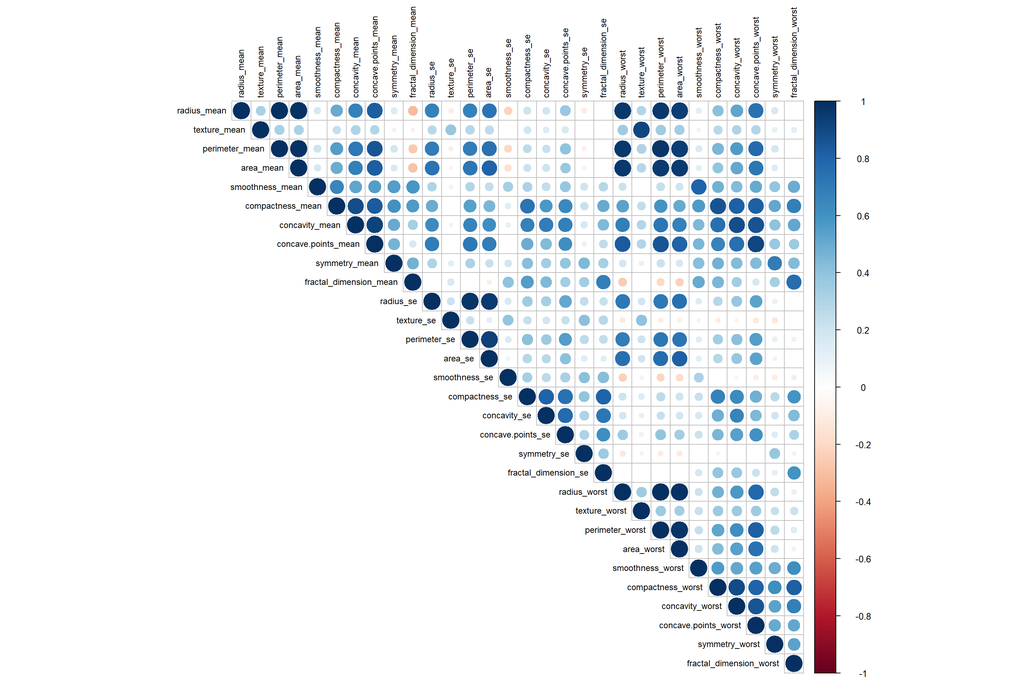

```r
DPA_CorrelationTest <- cor.mtest(DPA.Predictors.Numeric,
                       method = "pearson",
                       conf.level = 0.95)

corrplot(cor(DPA.Predictors.Numeric,
             method = "pearson",
             use="pairwise.complete.obs"),
             method = "circle",
             type = "upper",
             order = "original",
             tl.col = "black",
             tl.cex = 0.75,
             tl.srt = 90,
             sig.level = 0.05,
             p.mat = DPA_CorrelationTest$p,
             insig = "blank")
```

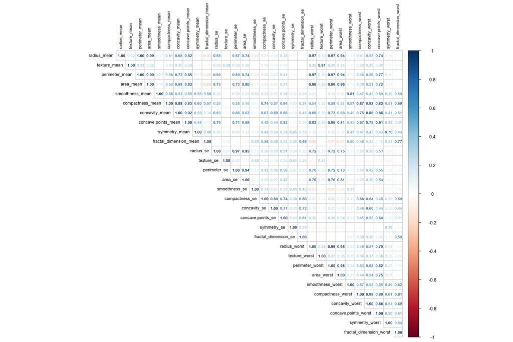

```r
corrplot(cor(DPA.Predictors.Numeric,
             method = "pearson",
             use="pairwise.complete.obs"),
             method = "number",
             type = "upper",
             order = "original",
             tl.col = "black",
             tl.cex = 0.75,
             tl.srt = 90,
             sig.level = 0.05,
             number.cex = 0.65,
             p.mat = DPA_CorrelationTest$p,
             insig = "blank")
```

```r
##################################
# Identifying the highly correlated variables
##################################
(DPA_HighlyCorrelatedCount <- sum(abs(DPA_Correlation[upper.tri(DPA_Correlation)])>0.95))
```

```
## [1] 15
```

```
## [1] "High correlation observed for 15 pairs of numeric variable(s) with Correlation.Coefficient>0.95."
```

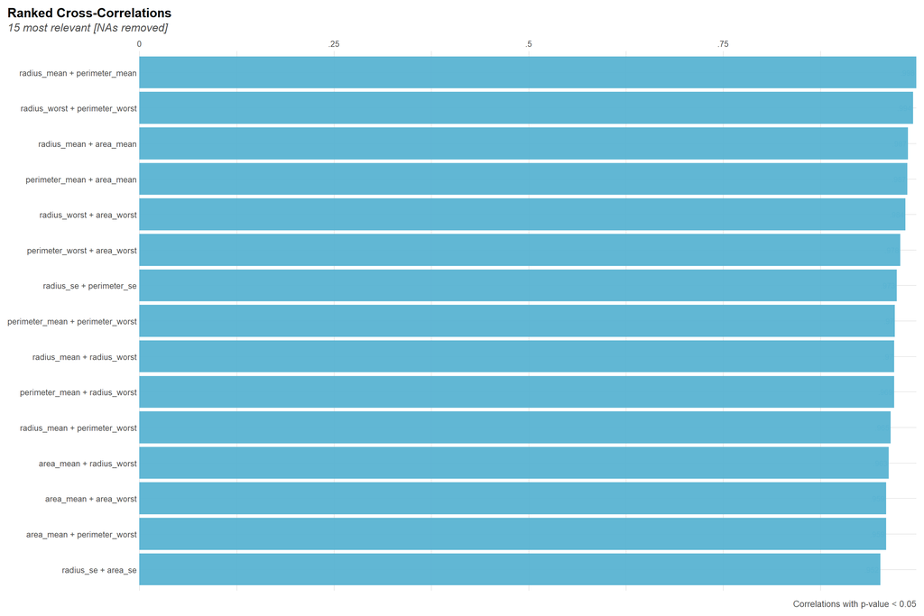

```r
if (DPA_HighlyCorrelatedCount == 0) {
  print("No highly correlated predictors noted.")
} else {
  print(paste0("High correlation observed for ",
               (DPA_HighlyCorrelatedCount),
               " pairs of numeric variable(s) with Correlation.Coefficient>0.95."))

  (DPA_HighlyCorrelatedPairs <- corr_cross(DPA.Predictors.Numeric,
  max_pvalue = 0.05,
  top = DPA_HighlyCorrelatedCount,
  rm.na = TRUE,
  grid = FALSE
))

}
```

```r
if (DPA_HighlyCorrelatedCount > 0) {
  DPA_HighlyCorrelated <- findCorrelation(DPA_Correlation, cutoff = 0.95)

  (DPA_HighlyCorrelatedForRemoval <- length(DPA_HighlyCorrelated))

  print(paste0("High correlation can be resolved by removing ",
               (DPA_HighlyCorrelatedForRemoval),
               " numeric variable(s)."))

  for (j in 1:DPA_HighlyCorrelatedForRemoval) {
  DPA_HighlyCorrelatedRemovedVariable <- colnames(DPA.Predictors.Numeric)[DPA_HighlyCorrelated[j]]
  print(paste0("Variable ",
               j,
               " for removal: ",
               DPA_HighlyCorrelatedRemovedVariable))
  }

}
```

```
## [1] "High correlation can be resolved by removing 7 numeric variable(s)."
## [1] "Variable 1 for removal: perimeter_worst"
## [1] "Variable 2 for removal: radius_worst"
## [1] "Variable 3 for removal: perimeter_mean"
## [1] "Variable 4 for removal: area_worst"
## [1] "Variable 5 for removal: radius_mean"
## [1] "Variable 6 for removal: perimeter_se"
## [1] "Variable 7 for removal: area_se"
```

### 1.3.4 Linear Dependency

**[A]** No linear dependencies noted for any subset of numeric variables using the preprocessing summary from the **caret** package applying the findLinearCombos method which utilizes the QR decomposition of a matrix to enumerate sets of linear combinations (if they exist).

**Code Chunk | Output**

```r
##################################
# Linear Dependencies
##################################

##################################
# Finding linear dependencies
##################################
DPA_LinearlyDependent <- findLinearCombos(DPA.Predictors.Numeric)

##################################
# Identifying the linearly dependent variables
##################################
DPA_LinearlyDependent <- findLinearCombos(DPA.Predictors.Numeric)

(DPA_LinearlyDependentCount <- length(DPA_LinearlyDependent$linearCombos))
```

```
## [1] 0
```

```r
if (DPA_LinearlyDependentCount == 0) {
  print("No linearly dependent predictors noted.")
} else {
  print(paste0("Linear dependency observed for ",
               (DPA_LinearlyDependentCount),
               " subset(s) of numeric variable(s)."))

  for (i in 1:DPA_LinearlyDependentCount) {
    DPA_LinearlyDependentSubset <- colnames(DPA.Predictors.Numeric)[DPA_LinearlyDependent$linearCombos[[i]]]
    print(paste0("Linear dependent variable(s) for subset ",
                 i,
                 " include: ",
                 DPA_LinearlyDependentSubset))
  }

}
```

```
## [1] "No linearly dependent predictors noted."
```

```r
##################################
# Identifying the linearly dependent variables for removal
##################################

if (DPA_LinearlyDependentCount > 0) {
  DPA_LinearlyDependent <- findLinearCombos(DPA.Predictors.Numeric)

  DPA_LinearlyDependentForRemoval <- length(DPA_LinearlyDependent$remove)

  print(paste0("Linear dependency can be resolved by removing ",
               (DPA_LinearlyDependentForRemoval),
               " numeric variable(s)."))

  for (j in 1:DPA_LinearlyDependentForRemoval) {
  DPA_LinearlyDependentRemovedVariable <- colnames(DPA.Predictors.Numeric)[DPA_LinearlyDependent$remove[j]]
  print(paste0("Variable ",
               j,
               " for removal: ",
               DPA_LinearlyDependentRemovedVariable))
  }

}
```

### 1.3.5 Distributional Shape

**[A]** Shape transformation was applied to improve against skewness and minimize outliers for data distribution stability using the BoxCox method from the **caret** package which transforms the distributional shape for predictors with strictly positive values.  
**[B]** Skewness measurements were improved for most except for 1 predictor with Skewness>3.  
**[B.1]** concavity_se = +5.10  
**[C]** Outliers were minimized for most except for 5 predictors which did not show any improvement even after shape transformation as noted using the IQR criterion.  
**[C.1]** concavity_mean = 36  
**[C.2]** concave.points_mean = 20  
**[C.3]** concavity_se = 44  
**[C.4]** concave.points_se = 38  
**[C.5]** concavity_worst = 24

**Code Chunk | Output**

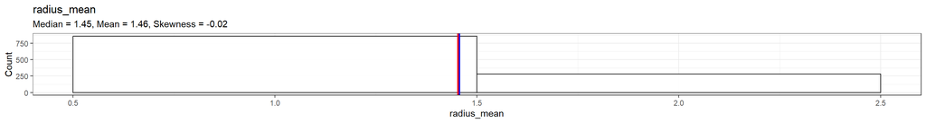

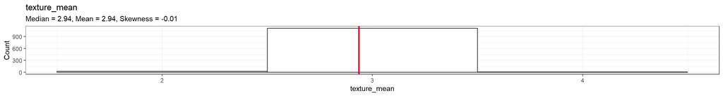

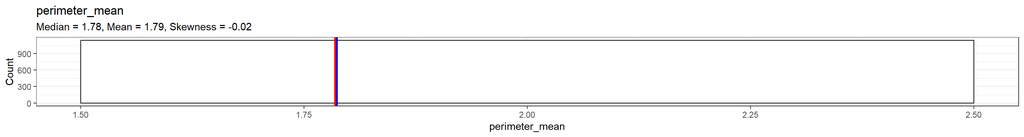

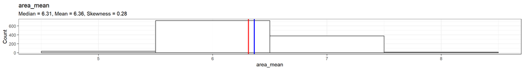

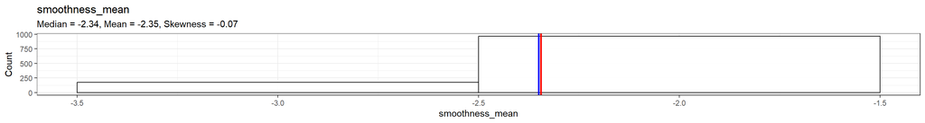

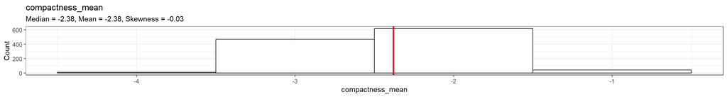

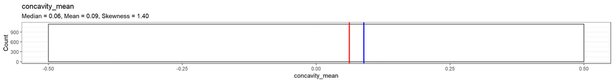

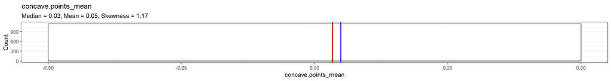

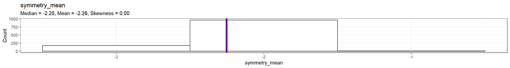

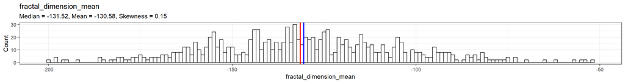

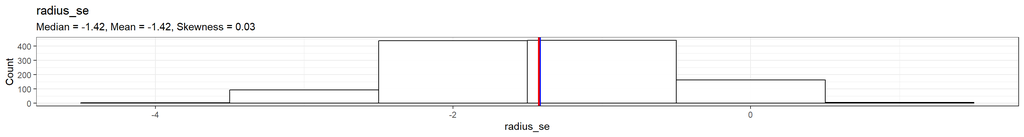

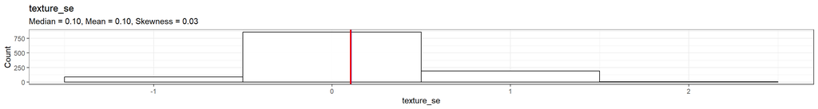

[18 more figures not shown]

```r
##################################
# Shape Transformation
##################################

##################################
# Applying a Box-Cox transformation
##################################
DPA_BoxCox <- preProcess(DPA.Predictors.Numeric, method = c("BoxCox"))
DPA_BoxCoxTransformed <- predict(DPA_BoxCox, DPA.Predictors.Numeric)

for (i in 1:ncol(DPA_BoxCoxTransformed)) {
  Median <- format(round(median(DPA_BoxCoxTransformed[,i],na.rm = TRUE),2), nsmall=2)
  Mean <- format(round(mean(DPA_BoxCoxTransformed[,i],na.rm = TRUE),2), nsmall=2)
  Skewness <- format(round(skewness(DPA_BoxCoxTransformed[,i],na.rm = TRUE),2), nsmall=2)
  print(
  ggplot(DPA_BoxCoxTransformed, aes(x=DPA_BoxCoxTransformed[,i])) +
  geom_histogram(binwidth=1,color="black", fill="white") +
  geom_vline(aes(xintercept=mean(DPA_BoxCoxTransformed[,i])),
            color="blue", size=1) +
    geom_vline(aes(xintercept=median(DPA_BoxCoxTransformed[,i])),
            color="red", size=1) +
  theme_bw() +
  ylab("Count") +
  xlab(names(DPA_BoxCoxTransformed)[i]) +
  labs(title=names(DPA_BoxCoxTransformed)[i],
       subtitle=paste0("Median = ", Median,
                       ", Mean = ", Mean,
                       ", Skewness = ", Skewness)))
}
```